# Lab 11

Blue Team: Matt Lawson, Brandon Bowen, Bing Mitchel, Nick Zimmerman

4/5/2019

# About `babynames` package

- Baby name data provided by the SSA (Social Security Administration)
- Includes names with at least 5 uses
- Includes year, sex, name, number of occurances, and prop
  - Prop = proportion of people of that sex with that name born in that year

## Individual plots of your nameâs popularity over time

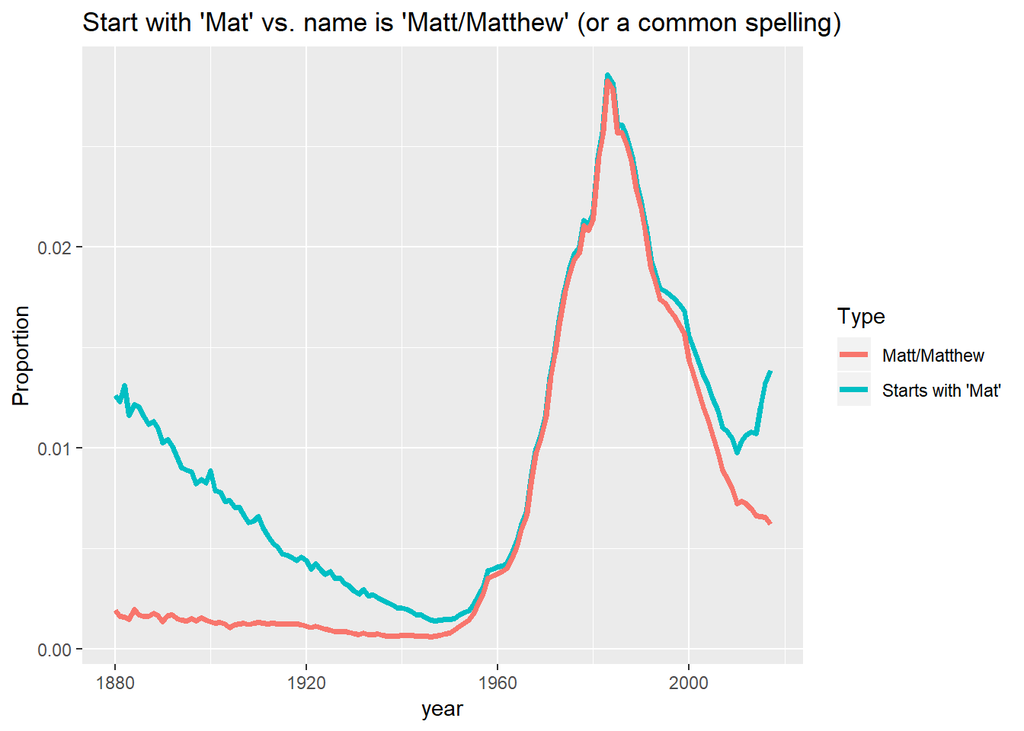

```r
startWithMat <- filter(babynames, str_detect(babynames$name, "^Mat")) %>% group_by(year) %>%
  summarize(sumprop = sum(prop))

Matt <- babynames %>%
  filter(str_detect(name, paste(c( "^Matthew$", "^Mathew$", "^Mat$", "^Matt$"),collapse = '|'))) %>%
  group_by(year) %>%
  summarize(sumprop = sum(prop))

ggplot() +
  geom_line(data=startWithMat, mapping=aes(x=year, y=sumprop, color="Starts with 'Mat'"), size=1.25) +
  geom_line(data=Matt, mapping=aes(x=year, y=sumprop, color="Matt/Matthew"), size=1.25) +
  labs(x="year", y="Proportion", title="Start with 'Mat' vs. name is 'Matt/Matthew' (or a common spelling)" , color="Type")
```

```r
nameNowBorn <- Matt %>% filter(year==1998 | year==2017)
startNowBorn <- startWithMat %>% filter(year==2017)


nameDif <- as.numeric(nameNowBorn[2,2] - nameNowBorn[1,2])
nowDif <- as.numeric(nameNowBorn[2,2] / startNowBorn[1,2] )

nameDif*100
```

```
## [1] -0.992258
```

```r
nowDif*100
```

```
## [1] 44.71288
```

## Bing

```r
Bing <- babynames %>%
  filter(str_detect(name, paste(c( "^Bingham$", "^Bing$"),collapse = '|'))) %>%
  group_by(year) %>%
  summarize( name = "Bingham", totalProp = sum(prop))

Bin <- babynames  %>% filter( str_detect(babynames$name, "^Bin")) %>% group_by(year) %>%
  summarize(name = "Bin",totalProp = sum(prop))

bingBirthYear <- subset(Bing, year == 1980 | year == 2017)

print(bingBirthYear)
```

```
## # A tibble: 2 x 3
##    year name     totalProp
##   <dbl> <chr>        <dbl>
## 1  1980 Bingham 0.0000027
## 2  2017 Bingham 0.00000509
```

[figure not shown]

```r
ggplot() +
geom_line(data = Bin, mapping=aes(x=year, y=totalProp), color="blue") +
  geom_line(data = Bing, mapping=aes(x=year, y=totalProp), color="orange") +
  geom_vline(xintercept = 1998, linetype= "solid", color = "red", size=0.25) +
  labs(title="Number of babies named 'Bingham' from 1979-2017", y="Proportion", caption="My birth year (1998) in red.")
```

## Nick

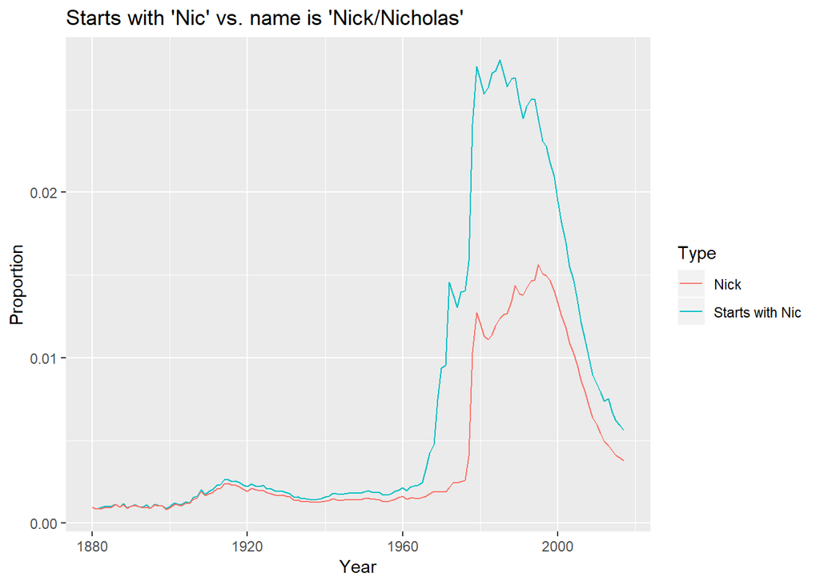

```r
startsWithNic <- babynames %>%
  filter(str_detect(babynames$name, "^Nic")) %>%
  group_by(year) %>% summarize(sumprop = sum(prop))

Nick <- babynames %>%
  filter(str_detect(name, paste(c( "^Ni(c|ck)$", "^Ni(c|ch)olas$"),collapse = '|'))) %>%
  group_by(year) %>% summarize(sumprop = sum(prop))


ggplot(mapping = aes(year,sumprop))+
  geom_line(data = startsWithNic, mapping = aes(color = "Starts with Nic")) +
  geom_line(data = Nick, mapping = aes(color = "Nick")) +
  labs(x="Year", y="Proportion", title="Starts with 'Nic' vs. name is 'Nick/Nicholas'" , color="Type")
```

This plot shows the proportions of babies named Nick (and spelling variations) and all babies with names that start with the letters ‘Nic’. As you can see they follow the same basic trends, but the larger one is so much larger because there are many female babies that were born that also have names that start with ‘Nic’ like “Nicole”,“Nicey”, etc.

## Brandon

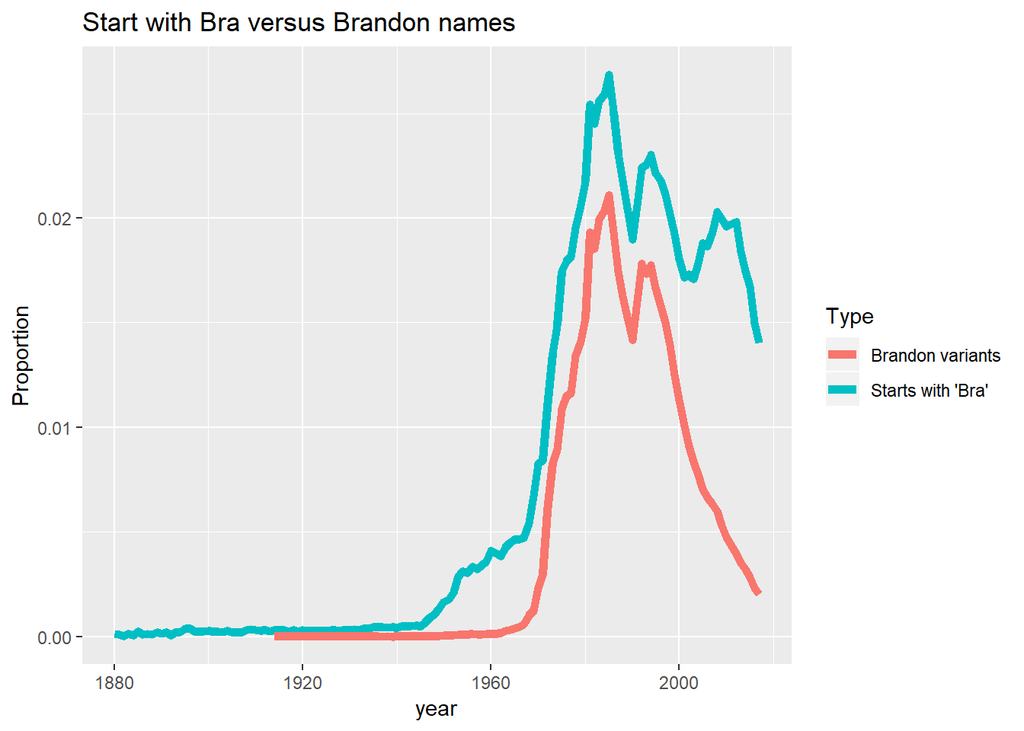

```r
startWithBra <- filter(babynames, str_detect(babynames$name, "^Bra")) %>% group_by(year) %>%
  summarize(sumprop = sum(prop))

Brandon <- babynames %>%
  filter(str_detect(name, paste(c( "^Brand"),collapse = '|'))) %>%
  group_by(year) %>%
  summarize(sumprop = sum(prop))

ggplot() +
  geom_line(data=startWithBra, mapping=aes(x=year, y=sumprop, color="Starts with 'Bra'"), size=2) +
  geom_line(data=Brandon, mapping=aes(x=year, y=sumprop, color="Brandon variants"), size=2) +
  labs(x="year", y="Proportion", title="Start with Bra versus Brandon names" , color="Type")
```

FOr my graph I only used the filter for names that start with Brand becuase in my research all names that have the samn origins as Brandon such as their english roots are only speeled differently at the end of their name such as an “an”, “en”, “yn”, “in” and more. Furthermore no other names that I could in the data with Brand as the beggining affect the data or the names with Brand originate from the same meaning even if speeled differently. My name since 1999 and all other forms has been drooping off in popularity increasingly

## Ariel and Rachel regexs

```r
ariel <- filter(babynames, str_detect(babynames$name, "Ar[iy]+.l+[^a]?$")) %>%
  filter(year==1973 | year==1988 | year==1990) %>%
  group_by(year, name) %>% summarize(count = sum(n), sumprop = sum(prop))

ariel1973 <- ariel %>% filter(year==1973) %>% nrow()
ariel1988 <- ariel %>% filter(year==1988) %>% nrow()
ariel1990 <- ariel %>% filter(year==1990) %>% nrow()
#############################################################################################################
rachel <- filter(babynames, str_detect(babynames$name, "Ra[ey]?ch.*l")) %>%
  filter(year==1973 | year==1988 | year==1990) %>%
  group_by(year, name) %>% summarize(count = sum(n), sumprop = sum(prop))

rachel1973 <- rachel %>% filter(year==1973) %>% nrow()
rachel1988 <- rachel %>% filter(year==1988) %>% nrow()
rachel1990 <- rachel %>% filter(year==1990) %>% nrow()


arielRachel <- tribble(
  ~Name, ~Year, ~`Unique Spellings`,
  "Ariel", 1973, ariel1973,
  "Ariel", 1988, ariel1988,
  "Ariel", 1990, ariel1990,
  "Rachel", 1973, rachel1973,
  "Rachel", 1988, rachel1988,
  "Rachel", 1990, rachel1990
)
```

**Number of different ways to spell [Ariel, Rachel] for different years**

| Name | Year | Unique Spellings |
| --- | --- | --- |
| Ariel | 1973 | 2 |
| Ariel | 1988 | 7 |
| Ariel | 1990 | 8 |
| Rachel | 1973 | 13 |
| Rachel | 1988 | 19 |
| Rachel | 1990 | 17 |

```r
ariel <- filter(babynames, str_detect(babynames$name, "Ar[iy]+.l+[^a]?$")) %>%
  filter(sex=="F" & (year==1973 | year==1988 | year==1990 | year==2017)) %>%
  group_by(year) %>% summarize(count = sum(n), sumprop = sum(prop)) %>% mutate(name="Ariel")

rachel <- filter(babynames, str_detect(babynames$name, "Ra[ey]?ch.*l")) %>%
  filter(sex=="F" & (year==1973 | year==1988 | year==1990 | year==2017)) %>%
 group_by(year) %>% summarize(count = sum(n), sumprop = sum(prop)) %>% mutate(name="Rachel")



total <- ariel %>% rbind(rachel) %>% arrange(year)  %>% group_by(year) %>% summarize(totalProp = sum(sumprop))
names(total)[2] <- "Chance"
```

**Chances a girl would be named either Rachel or Ariel (Including different spellings) for the given year**

| year | Chance |
| --- | --- |
| 1973 | 0.00540399 |
| 1988 | 0.01121563 |
| 1990 | 0.01252940 |
| 2017 | 0.00267214 |

## The *Little Mermaid* Effect

**Did The Little Mermaid cause more baby girls to be named Ariel (and various spellings)?**

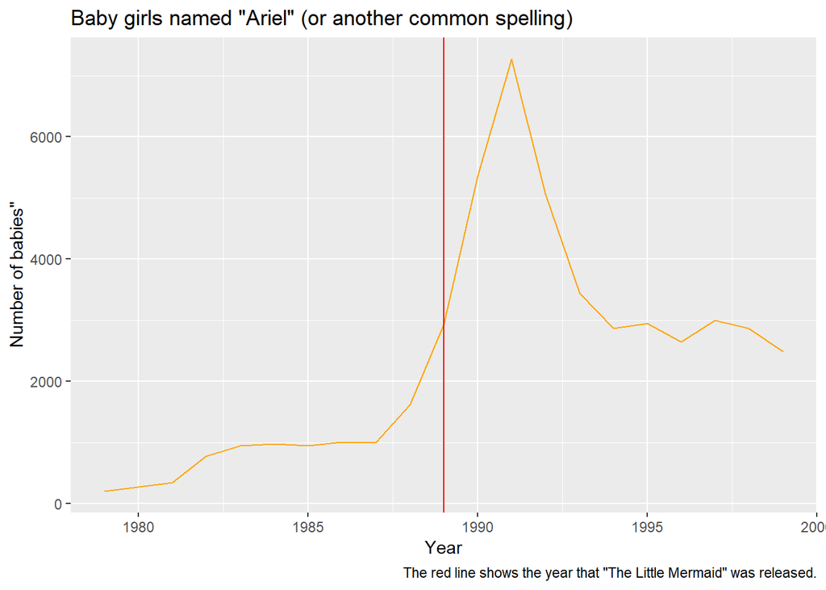

From the year before the movie released to 2 years after the movie released, the number of baby girls named “Ariel” rose from under 2000 to over 7000. But how did the number of baby girls increase in that time?

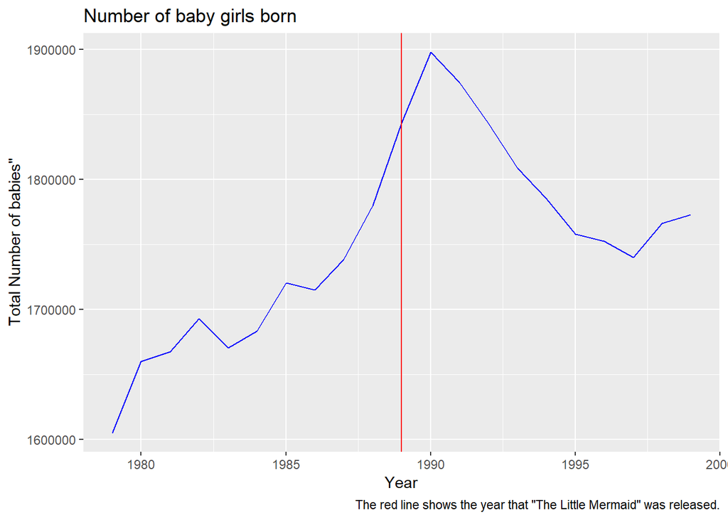

## Your names

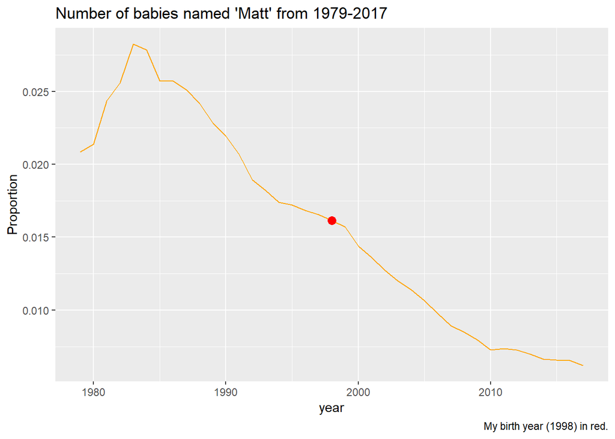

```r
Matt <- babynames %>% filter(year<=2017 & year>=1979) %>%
  filter(str_detect(name, paste(c( "^Matthew$", "^Mathew$", "^Mat$", "^Matt$"),collapse = '|'))) %>%
  group_by(year) %>%
  summarize( name = "Matthew", totalProp = sum(prop))
mattBirthYear <- subset(Matt, year == 1998)
ggplot() +
  geom_line(data = Matt, mapping=aes(x=year, y=totalProp), color="orange") +
  geom_point(dat=mattBirthYear, mapping=aes(x=year, y=totalProp), color="red", size=3) +
  labs(title="Number of babies named 'Matt' from 1979-2017", y="Proportion", caption="My birth year (1998) in red.")
```

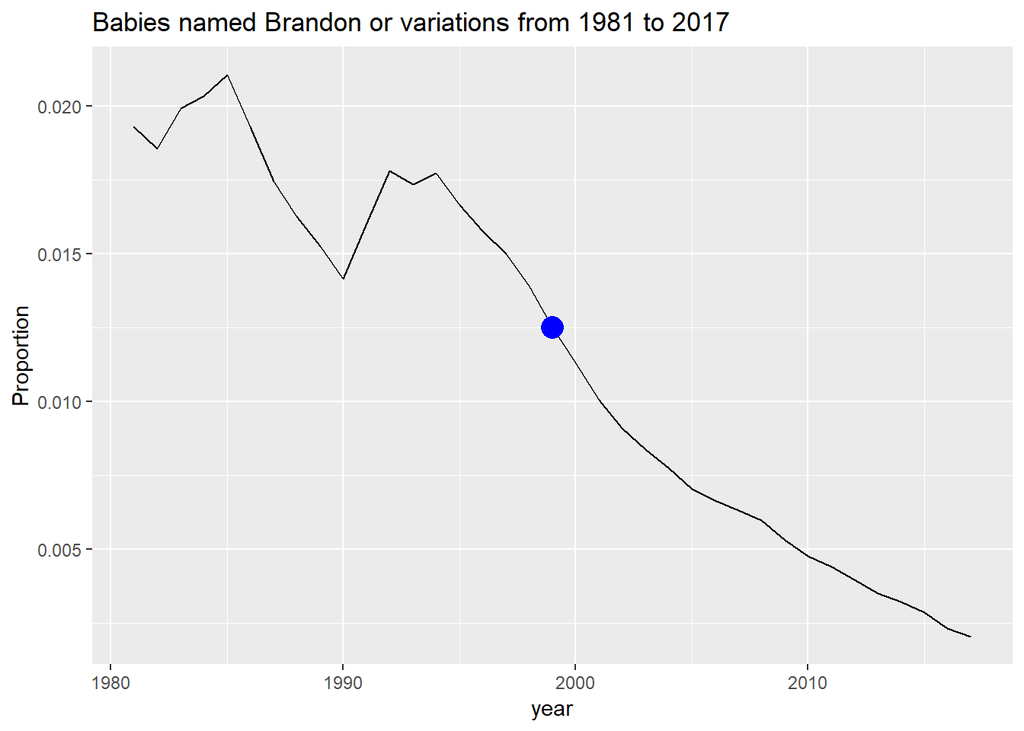

```r
Brand <- babynames %>% filter(year<=2017 & year>=1981) %>%
  filter(str_detect(name, paste(c( "^Brand" ),collapse = '|'))) %>%
  group_by(year) %>%
  summarize( name = "Brandon", totalProp = sum(prop))
BirthYear <- subset(Brand, year == 1999)
ggplot() +
  geom_line(data = Brand, mapping=aes(x=year, y=totalProp), color="black") +
  geom_point(dat= BirthYear, mapping=aes(x=year, y=totalProp), color="blue", size=5) +
  labs(title="Babies named Brandon or variations from 1981 to 2017", y="Proportion")
```

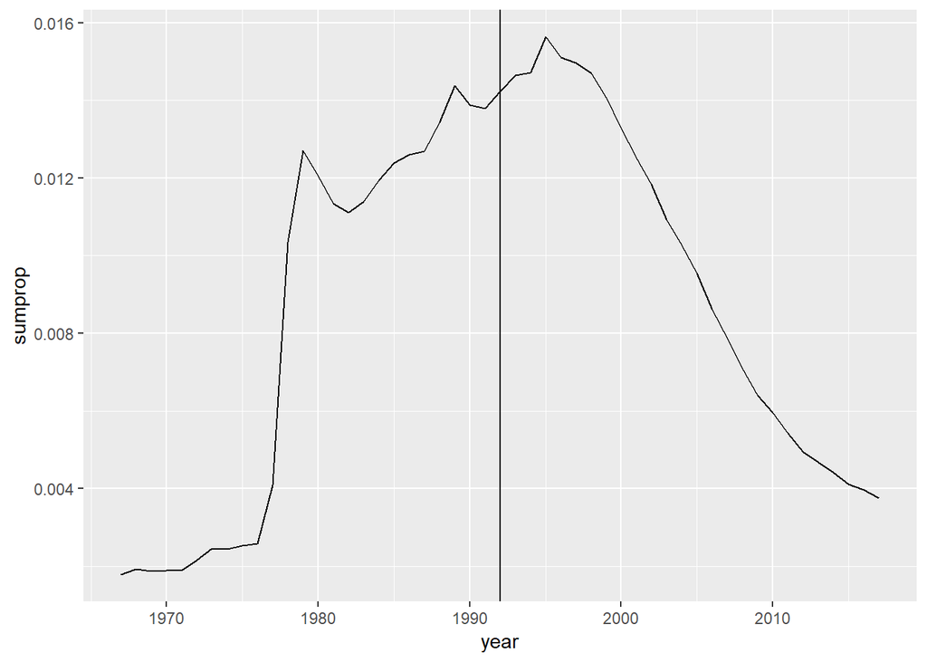

```r
Nick <- babynames %>% filter(year <= 2017 & year >= 1967) %>%
    filter(str_detect(name, paste(c( "^Ni(c|ck)$", "^Ni(c|ch)olas$"),collapse = '|')))

ggplot(data = Nick %>% group_by(year) %>% summarize(sumprop = sum(prop))) +
  geom_line(mapping = aes(x= year, y= sumprop))+
  geom_vline(xintercept = 1992)
```

## Name changes over the years

From the three names we have Both Brandon and Matt’s name have been on a steady decline with Brandon’s name on lowest end of popularity. For the name Nick and other various spellings it ddin’t go on a decline until 1995 where it decreased alot in popularity

## Who Did What

**Matt**

- Created and setup the team markdown file
- Created the template for the name popularity over time
- Completed the Ariel and Rachel Regex section
- Worked on *The Little Mermaid* Effect section
- Created the template for the first plot of the names section

**Brandon**

-Created indivdual plots -helped answer the team Questions. -Provided data for the Little mermaid effect.

**Bing**

Created Individual Plot

**Nick**

Created individual plot

# Lab 11

Blue Team: Matt Lawson,

4/5/2019

# About `babynames` package

- Baby name data provided by the SSA (Social Security Administration)
- Includes names with at least 5 uses
- Includes year, sex, name, number of occurances, and prop
  - Prop = proportion of people of that sex with that name born in that year

## Individual plots of your name’s popularity over time

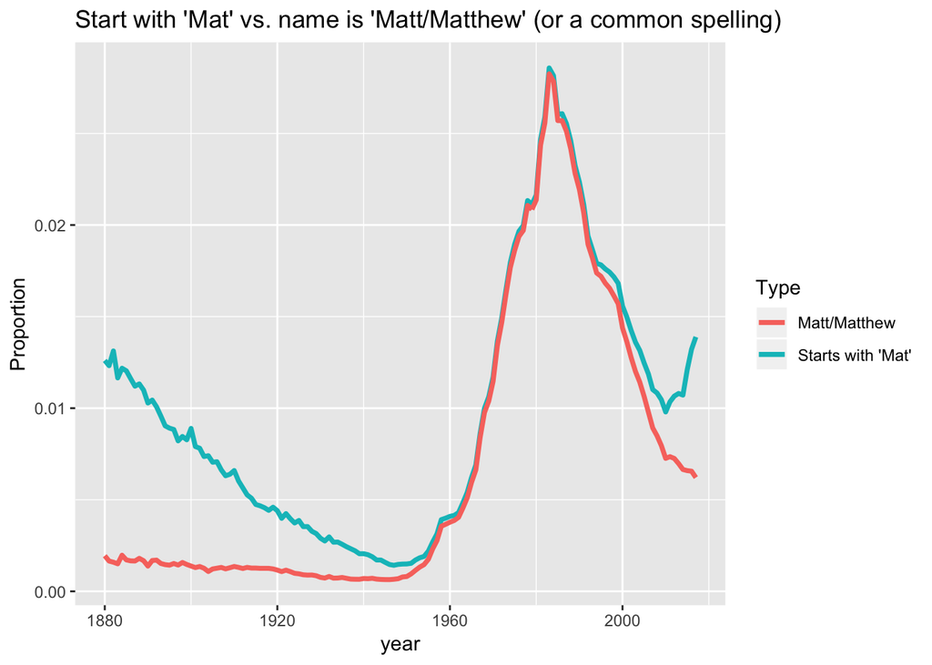

```r
startWithMat <- filter(babynames, str_detect(babynames$name, "^Mat")) %>% group_by(year) %>%
  summarize(sumprop = sum(prop))

Matt <- babynames %>%
  filter(str_detect(name, paste(c( "^Matthew$", "^Mathew$", "^Mat$", "^Matt$"),collapse = '|'))) %>%
  group_by(year) %>%
  summarize(sumprop = sum(prop))

ggplot() +
  geom_line(data=startWithMat, mapping=aes(x=year, y=sumprop, color="Starts with 'Mat'"), size=1.25) +
  geom_line(data=Matt, mapping=aes(x=year, y=sumprop, color="Matt/Matthew"), size=1.25) +
  labs(x="year", y="Proportion", title="Start with 'Mat' vs. name is 'Matt/Matthew' (or a common spelling)" , color="Type")
```

```r
nameNowBorn <- Matt %>% filter(year==1998 | year==2017)
startNowBorn <- startWithMat %>% filter(year==2017)


nameDif <- as.numeric(nameNowBorn[2,2] - nameNowBorn[1,2])
nowDif <- as.numeric(nameNowBorn[2,2] / startNowBorn[1,2] )

nameDif*100
```

```
## [1] -0.992258
```

```r
nowDif*100
```

```
## [1] 44.71288
```

## Nick

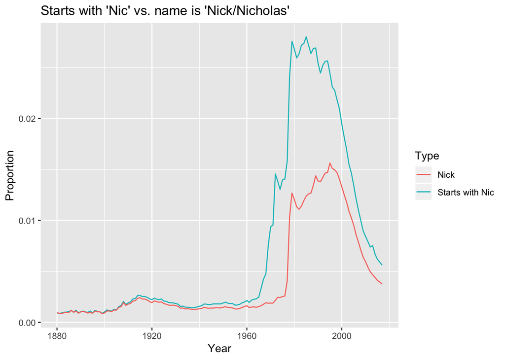

```r
startsWithNic <- babynames %>%
  filter(str_detect(babynames$name, "^Nic")) %>%
  group_by(year) %>% summarize(sumprop = sum(prop))

Nick <- babynames %>%
  filter(str_detect(name, paste(c( "^Ni(c|ck)$", "^Ni(c|ch)olas$"),collapse = '|'))) %>%
  group_by(year) %>% summarize(sumprop = sum(prop))


ggplot(mapping = aes(year,sumprop))+
  geom_line(data = startsWithNic, mapping = aes(color = "Starts with Nic")) +
  geom_line(data = Nick, mapping = aes(color = "Nick")) +
  labs(x="Year", y="Proportion", title="Starts with 'Nic' vs. name is 'Nick/Nicholas'" , color="Type")
```

This plot shows the proportions of babies named Nick (and spelling variations) and all babies with names that start with the letters ‘Nic’. As you can see they follow the same basic trends, but the larger one is so much larger because there are many female babies that were born that also have names that start with ‘Nic’ like “Nicole”,“Nicey”, etc.

## Ariel and Rachel regexs

```r
ariel <- filter(babynames, str_detect(babynames$name, "Ar[iy]+.l+[^a]?$")) %>%
  filter(year==1973 | year==1988 | year==1990) %>%
  group_by(year, name) %>% summarize(count = sum(n), sumprop = sum(prop))

ariel1973 <- ariel %>% filter(year==1973) %>% nrow()
ariel1988 <- ariel %>% filter(year==1988) %>% nrow()
ariel1990 <- ariel %>% filter(year==1990) %>% nrow()
#############################################################################################################
rachel <- filter(babynames, str_detect(babynames$name, "Ra[ey]?ch.*l")) %>%
  filter(year==1973 | year==1988 | year==1990) %>%
  group_by(year, name) %>% summarize(count = sum(n), sumprop = sum(prop))

rachel1973 <- rachel %>% filter(year==1973) %>% nrow()
rachel1988 <- rachel %>% filter(year==1988) %>% nrow()
rachel1990 <- rachel %>% filter(year==1990) %>% nrow()


arielRachel <- tribble(
  ~Name, ~Year, ~`Unique Spellings`,
  "Ariel", 1973, ariel1973,
  "Ariel", 1988, ariel1988,
  "Ariel", 1990, ariel1990,
  "Rachel", 1973, rachel1973,
  "Rachel", 1988, rachel1988,
  "Rachel", 1990, rachel1990
)
```

**Number of different ways to spell [Ariel, Rachel] for different years**

| Name | Year | Unique Spellings |
| --- | --- | --- |
| Ariel | 1973 | 2 |
| Ariel | 1988 | 7 |
| Ariel | 1990 | 8 |
| Rachel | 1973 | 13 |
| Rachel | 1988 | 19 |
| Rachel | 1990 | 17 |

```r
ariel <- filter(babynames, str_detect(babynames$name, "Ar[iy]+.l+[^a]?$")) %>%
  filter(sex=="F" & (year==1973 | year==1988 | year==1990 | year==2017)) %>%
  group_by(year) %>% summarize(count = sum(n), sumprop = sum(prop)) %>% mutate(name="Ariel")

rachel <- filter(babynames, str_detect(babynames$name, "Ra[ey]?ch.*l")) %>%
  filter(sex=="F" & (year==1973 | year==1988 | year==1990 | year==2017)) %>%
 group_by(year) %>% summarize(count = sum(n), sumprop = sum(prop)) %>% mutate(name="Rachel")



total <- ariel %>% rbind(rachel) %>% arrange(year)  %>% group_by(year) %>% summarize(totalProp = sum(sumprop))
names(total)[2] <- "Chance"
```

**Chances a girl would be named either Rachel or Ariel (Including different spellings) for the given year**

| year | Chance |
| --- | --- |
| 1973 | 0.00540399 |
| 1988 | 0.01121563 |
| 1990 | 0.01252940 |
| 2017 | 0.00267214 |

## The *Little Mermaid* Effect

**Did The Little Mermaid cause more baby girls to be named Ariel (and various spellings)?**

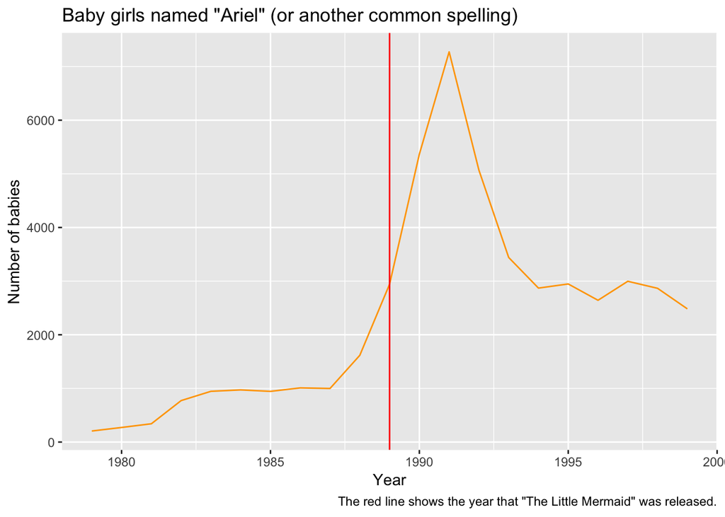

From the year before the movie released to 2 years after the movie released, the number of baby girls named “Ariel” rose from under 2000 to over 7000. But how did the number of baby girls increase in that time?

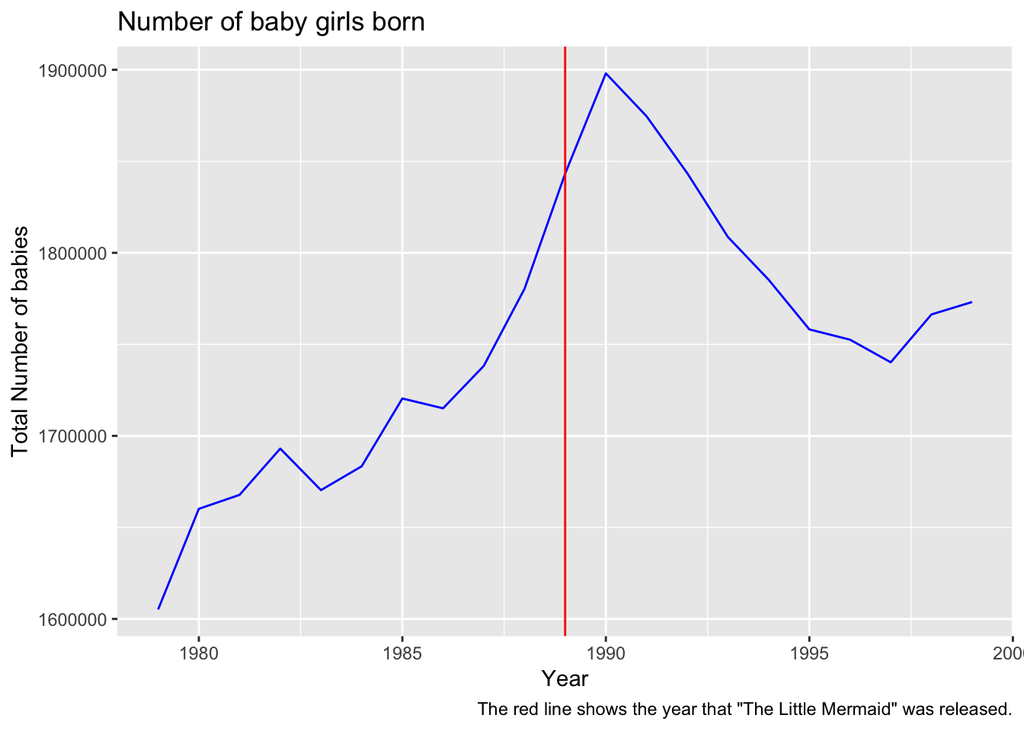

```r
startWithVowel <- babynames %>%
  filter(str_detect(name, "^[AEIOUaeiou]")) %>%
  filter(between(year, 1988, 1990) & sex=="F") %>%
  group_by(year) %>%
  summarize(name="Starts with vowel", n = sum(n), prop = sum(prop))

ariel <-  babynames %>%
  filter(str_detect(name, "Ar[iy]+.l+[^a]?$")) %>%
  filter(between(year, 1988, 1990) & sex=="F") %>%
  group_by(year) %>%
  summarize(name="Ariel", n = sum(n), prop = sum(prop))

startWithVowel <- rbind(ariel, startWithVowel)
startWithVowel
```

| year | name | n | prop |
| --- | --- | --- | --- |
| 1988 | Ariel | 1617 | 0.00084105 |
| 1989 | Ariel | 2942 | 0.00147697 |
| 1990 | Ariel | 5366 | 0.00261250 |
| 1988 | Starts with vowel | 352625 | 0.18341041 |
| 1989 | Starts with vowel | 366852 | 0.18417180 |
| 1990 | Starts with vowel | 381460 | 0.18571714 |

## Your names

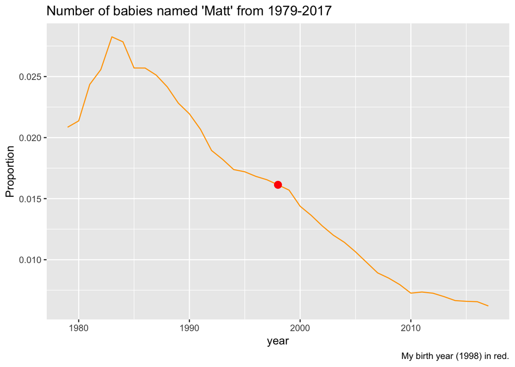

```r
Matt <- babynames %>% filter(year<=2017 & year>=1979) %>%
  filter(str_detect(name, paste(c( "^Matthew$", "^Mathew$", "^Mat$", "^Matt$"),collapse = '|'))) %>%
  group_by(year) %>%
  summarize( name = "Matthew", totalProp = sum(prop))
mattBirthYear <- subset(Matt, year == 1998)
ggplot() +
  geom_line(data = Matt, mapping=aes(x=year, y=totalProp), color="orange") +
  geom_point(dat=mattBirthYear, mapping=aes(x=year, y=totalProp), color="red", size=3) +
  labs(title="Number of babies named 'Matt' from 1979-2017", y="Proportion", caption="My birth year (1998) in red.")
```

## Who Did What

**Matt**

- Created and setup the team markdown file
- Created the template for the name popularity over time
- Completed the Ariel and Rachel Regex section
- Worked on *The Little Mermaid* Effect section
- Created the template for the first plot of the names section

**Brandon**

**Bing**

**Nick**

Created individual plot